# Machine Learning: Mathematical Theory and Applications

Computer lab 1

Matias Quiroz

Published

August 28, 2025

**Warning**

The instructions in this lab assume that the following packages are installed:

- `splines`
- `caret`

Packages may be installed by executing `install.packages('packagename')`, where `'packagename'` is the name of the package, e.g. `'splines'`. You may have to install additional packages to solve the computer lab. If you want this file to run locally on your computer, you have to change some paths to where the data are stored (see below).

## Introduction

This computer lab corresponds to Module 1 and treats topics such as polynomial and spline regression, regularisation, cross-validation, regression and decision trees, and classification methods.

**Instructions**

In this computer lab, you will work individually but you are free to discuss with other students, especially the one student you will work with on Computer lab 2! However, you have to hand in your own set of solutions. **It is strictly forbidden to copy anyone else’s code or solutions**. This is regarded as academic misconduct and may have serious consequences for you. **Irresponsible use of AI tools (such as ChatGPT) is not recommended**. Keep in mind that such tools are not permitted in the invigilated final project.

This computer lab is worth a total of 15 marks (the subject has a maximum of 100 marks). The maximum marks for a given problem is shown within parenthesis at the top of the section. The marking rubric is available on Canvas. The problems you should solve are marked with the symbol 💪 and surrounded by a box. Hand in the solutions and programming codes in any form you like, however, I will not be accepting any obscure .docx or .xlsx files (convert to pdf if needed). You are encouraged to learn how to use Quarto to generate scientific and technical reports. (This computer lab is typeset in Quarto.) A Quarto template on Canvas is provided for this purpose. If you use Quarto, hand in the report in the form of a html document generated by Quarto. **Before submitting, carefully check that the document compiles without any errors**. Use properly formatted figures and programming code.

**Warning**

Submitting poorly written reports may result in loss of marks. The same applies to poorly formatted reports (including poorly formatted code/figures, unnecessarily long outputs, etc.).

## 1. Polynomial regression for bike rental data (2 marks)

In this problem, we consider modelling the number of rides each hour for a bike rental company. The raw data are stored in the file `bike_rental_hourly.csv`, which can be downloaded from the Canvas page of the course[^1].

The dataset contains 17379 hourly observations over the two-year period January 1, 2011 - December 31, 2012. The dataset contains many features that may be useful for predicting the number of rides, such as the hour of the day, temperature, humidity, season, weekday, etc. In this section, we consider modelling the logarithm of the number of rides as a function of the time of the day (scaled to the interval [0,1], see below). The following code reads in the data (note that you have to change to the path were you stored the file!) and creates the variables of interest (`log_cnt` and `hour`)

```r
rm(list=ls()) # Remove variables
cat("\014") # Clean workspace
```

```r
bike_data <- read.csv('C:/Users/TSC/Desktop/UTS/Sem 1/Machine Learning/Cmp Lab 1/bike_rental_hourly.csv')
str(bike_data)
```

```
'data.frame':   17379 obs. of  17 variables:
 $ instant   : int  1 2 3 4 5 6 7 8 9 10 ...
 $ dteday    : chr  "2011-01-01" "2011-01-01" "2011-01-01" "2011-01-01" ...
 $ season    : int  1 1 1 1 1 1 1 1 1 1 ...
 $ yr        : int  0 0 0 0 0 0 0 0 0 0 ...
 $ mnth      : int  1 1 1 1 1 1 1 1 1 1 ...
 $ hr        : int  0 1 2 3 4 5 6 7 8 9 ...
 $ holiday   : int  0 0 0 0 0 0 0 0 0 0 ...
 $ weekday   : int  6 6 6 6 6 6 6 6 6 6 ...
 $ workingday: int  0 0 0 0 0 0 0 0 0 0 ...
 $ weathersit: int  1 1 1 1 1 2 1 1 1 1 ...
 $ temp      : num  0.24 0.22 0.22 0.24 0.24 0.24 0.22 0.2 0.24 0.32 ...
 $ atemp     : num  0.288 0.273 0.273 0.288 0.288 ...
 $ hum       : num  0.81 0.8 0.8 0.75 0.75 0.75 0.8 0.86 0.75 0.76 ...
 $ windspeed : num  0 0 0 0 0 0.0896 0 0 0 0 ...
 $ casual    : int  3 8 5 3 0 0 2 1 1 8 ...
 $ registered: int  13 32 27 10 1 1 0 2 7 6 ...
 $ cnt       : int  16 40 32 13 1 1 2 3 8 14 ...
```

```r
head(bike_data)
```

```
  instant     dteday season yr mnth hr holiday weekday workingday weathersit
1       1 2011-01-01      1  0    1  0       0       6          0          1
2       2 2011-01-01      1  0    1  1       0       6          0          1
3       3 2011-01-01      1  0    1  2       0       6          0          1
4       4 2011-01-01      1  0    1  3       0       6          0          1
5       5 2011-01-01      1  0    1  4       0       6          0          1
6       6 2011-01-01      1  0    1  5       0       6          0          2
  temp  atemp  hum windspeed casual registered cnt
1 0.24 0.2879 0.81    0.0000      3         13  16
2 0.22 0.2727 0.80    0.0000      8         32  40
3 0.22 0.2727 0.80    0.0000      5         27  32
4 0.24 0.2879 0.75    0.0000      3         10  13
5 0.24 0.2879 0.75    0.0000      0          1   1
6 0.24 0.2576 0.75    0.0896      0          1   1
```

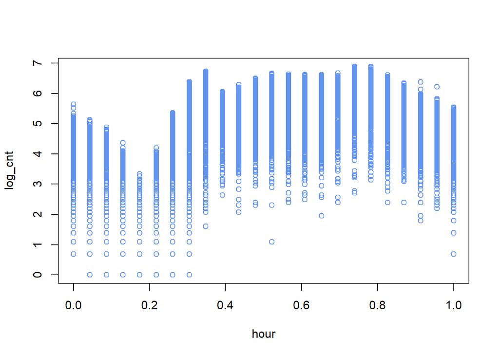

```r
bike_data$log_cnt <- log(bike_data$cnt)
bike_data$hour <- bike_data$hr/23 # transform [0, 23] to [0, 1]. 0 is midnight, 1 is 11 PM
plot(log_cnt ~ hour, data = bike_data, col = "cornflowerblue")
```

The number of rides seem to peak in the morning (8 AM $8/23 \approx 0.35$ ) and after work (6 PM $18/23 \approx 0.78$).

We start by fitting a polynomial of order 2 to a training dataset consisting of Feb 1, 2011 - March 31, 2011. We use the following two months (April 1, 2011 - May 31, 2011) as test dataset to evaluate the predictions. The following code creates the training and test datasets.

```r
bike_data_train <- bike_data[bike_data$dteday >= as.Date("2011-02-01") & bike_data$dteday <=  as.Date("2011-03-31"), ]
bike_data_test <- bike_data[bike_data$dteday >= as.Date("2011-04-01") & bike_data$dteday <=  as.Date("2011-05-31"), ]
```

The following code estimates the model (a polynomial of order 2) using least squares and computes the root mean squared error (RMSE) for both the training data and the test data. Moreover, the code plots the training data, test data and the fitted polynomial in the same plot.

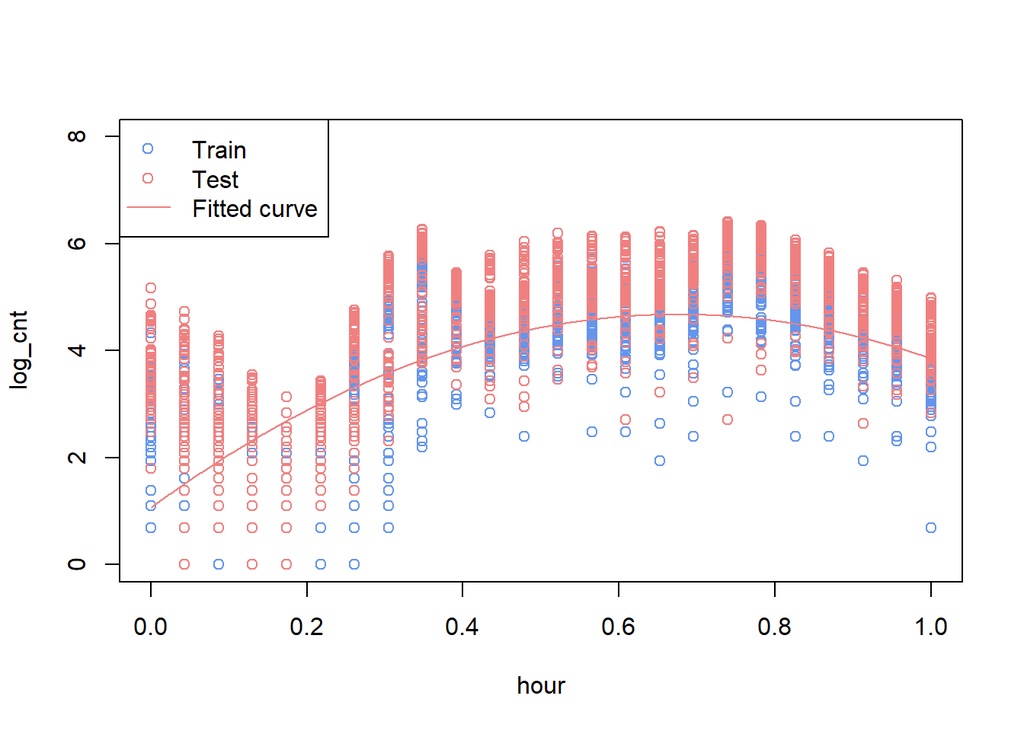

```r
y_train <- bike_data_train$log_cnt
y_test <- bike_data_test$log_cnt
p <- 2 # Order of polynomial
X_train <- cbind(1, poly(bike_data_train$hour, p, raw = TRUE, simple = TRUE)) # Design mmatrix of features (including intercept)
beta_hat <- solve(t(X_train)%*%X_train)%*%t(X_train)%*%y_train

# Predict in-sample and compute RMSE
y_hat_train <- X_train%*%beta_hat
RMSE_train <- sqrt(sum((y_train - y_hat_train)^2)/length(y_train))

# Predict out-of-sample and compute RMSE
X_test <- cbind(1, poly(bike_data_test$hour, p, raw = TRUE, simple = TRUE))
y_hat_test <- X_test%*%beta_hat
RMSE_test <- sqrt(sum((y_test - y_hat_test)^2)/length(y_test))

# Plot training data, test data, and fit on a fine grid.
plot(log_cnt ~ hour, data = bike_data_train, col = "cornflowerblue", ylim = c(0, 8))
lines(bike_data_test$hour, bike_data_test$log_cnt, type = "p", col = "lightcoral")
hours_grid <- seq(0, 1, length.out = 1000)
X_grid <- cbind(1, poly(hours_grid, p, raw = TRUE, simple = TRUE))
y_hat_grid <- X_grid%*%beta_hat
lines(hours_grid, y_hat_grid, lty = 1, col = "lightcoral")
legend(x = "topleft", pch = c(1, 1, NA), lty = c(NA, NA, 1), col = c("cornflowerblue", "lightcoral",  "lightcoral"), legend=c("Train", "Test", "Fitted curve"))
```

#### 💪 Problem 1.1

Fit a polynomial of order 8 using least squares, without using R functions such as `lm()`. Plot the training data, test data and the fitted polynomial in the same plot.

```r
#=== 1.Prepare data
#Training data and test data are determined above in the problem requirement.

y_train <- bike_data_train$log_cnt
y_test <- bike_data_test$log_cnt
p <- 8 #Order of polynominal

#=== 2.Design matrix of features (including intercept)
xpoly_train <- cbind(1, poly(bike_data_train$hour, p ,raw = TRUE, simple = TRUE))
xpoly_test <- cbind(1, poly(bike_data_test$hour, p , raw = TRUE, simple = TRUE))
beta_hat <- solve(t(xpoly_train)%*%xpoly_train)%*%t(xpoly_train)%*%y_train

#=== 3.Predict in-sample and out-of-sample y hat
ypoly_hat_train <- xpoly_train%*%beta_hat
ypoly_hat_test <- xpoly_test%*%beta_hat

#=== 3.Compute RMSE
RMSE_train_poly <- sqrt (mean((y_train - ypoly_hat_train)^2))
RMSE_test_poly <- sqrt(mean((y_test - ypoly_hat_test)^2))
cat("RMSE (Train):", RMSE_train_poly, "\n")
```

```
RMSE (Train): 0.7232024
```

```r
cat ("RMSE (Test):", RMSE_test_poly, "\n")
```

```
RMSE (Test): 1.021449
```

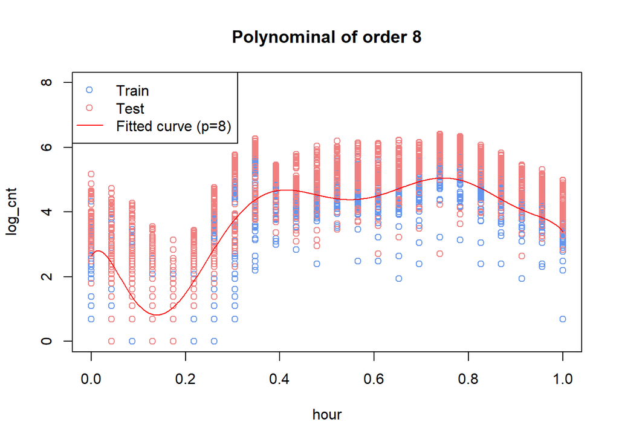

```r
#=== 4.Plot training data, test data, and fit on a fine grid
plot (log_cnt ~ hour, data = bike_data_train, col = "cornflowerblue", ylim = c(0,8), main = "Polynominal of order 8")
lines(bike_data_test$hour, bike_data_test$log_cnt, type = "p", col = "lightcoral")

hours_grid <- seq(0,1, length.out = 1000) #create a prediction grid matrix, run from 0 to 1, which is the all the value of variable x in the range [0,1]
x_grid <- cbind(1, poly(hours_grid, p, raw = TRUE, simple = TRUE))
y_hat_grid <- x_grid%*%beta_hat
lines (hours_grid, y_hat_grid, lty = 1, col = "red")

legend (x = "topleft", pch = c(1 , 1, NA), lty = c(NA, NA, 1), col = c("cornflowerblue", "lightcoral", "red"), legend = c ("Train", "Test", "Fitted curve (p=8)"))
```